# Table of Contents

```python
import json
import requests
import numpy as np
import pandas as pd
from datetime import datetime
from datetime import date
import csv
import urllib.request as urllib2
import dask.dataframe as dd
import glob
import os
from sklearn.model_selection import train_test_split
from sklearn.tree import DecisionTreeClassifier
from sklearn import linear_model
from sklearn.linear_model import LinearRegression
from sklearn.metrics import mean_squared_error
from sklearn.metrics import confusion_matrix
from sklearn.preprocessing import StandardScaler
from sklearn.ensemble import RandomForestClassifier
from sklearn.metrics import classification_report,confusion_matrix
from sklearn import metrics
import statsmodels.api as sm
import ijson
import time
import matplotlib.pyplot as plt
%matplotlib inline
import seaborn as sns
import re
import math
import statsmodels.formula.api as smf
from statsmodels.stats.outliers_influence import variance_inflation_factor
from patsy import dmatrices
```

### Question 1 - Which type of complaints The Department of Housing Preservation and Development of New York City should focus first?

#### Which type of complaint should the Department of Housing Preservation and Development of New York City focus on first?

```python
file='C:/Users/tuncay/Documents/311_Service_Requests_from_2010_to_Present.csv'
df=pd.read_csv(file)
```

[output not shown]

1 rows × 41 columns

```python
df['Created Date'] = pd.to_datetime(df['Created Date'],errors="coerce")
df['Hour'] = df["Created Date"].dt.strftime('%H')
df['Day'] = df["Created Date"].dt.strftime('%d')
df['Month'] = df["Created Date"].dt.strftime('%m')
df['Year'] = df["Created Date"].dt.strftime('%Y')
```

```python
df.head(1)
```

|  | Unique Key | Created Date | Closed Date | Agency | Agency Name | Complaint Type | Descriptor | Location Type | Incident Zip | Incident Address | ... | Bridge Highway Segment | Latitude | Longitude | Location | Incident Zip2 | Complaint Type 2 | Hour | Day | Month | Year |
| --- | --- | --- | --- | --- | --- | --- | --- | --- | --- | --- | --- | --- | --- | --- | --- | --- | --- | --- | --- | --- | --- |
| 0 | 37344115 | 2017-10-03 11:21:00 | 10/03/2017 11:21:00 AM | DOT | Department of Transportation | Street Light Condition | Street Light Out | NaN | 11379 | NaN | ... | NaN | 40.718251 | -73.873581 | (40.718250994436765, -73.87358084321393) | NaN | 217 | 11 | 03 | 10 | 2017 |

1 rows × 47 columns

```python
df.columns
```

[output not shown]

```python
df.info()
```

```
<class 'pandas.core.frame.DataFrame'>
RangeIndex: 20219611 entries, 0 to 20219610
Data columns (total 41 columns):
Unique Key                        int64
Created Date                      object
Closed Date                       object
Agency                            object
Agency Name                       object
Complaint Type                    object
Descriptor                        object
Location Type                     object
Incident Zip                      object
Incident Address                  object
Street Name                       object
Cross Street 1                    object
Cross Street 2                    object
Intersection Street 1             object
Intersection Street 2             object
Address Type                      object
City                              object
Landmark                          object
Facility Type                     object
Status                            object
Due Date                          object
Resolution Description            object
Resolution Action Updated Date    object
Community Board                   object
BBL                               float64
Borough                           object
X Coordinate (State Plane)        float64
Y Coordinate (State Plane)        float64
Open Data Channel Type            object
Park Facility Name                object
Park Borough                      object
Vehicle Type                      object
Taxi Company Borough              object
Taxi Pick Up Location             object
Bridge Highway Name               object
Bridge Highway Direction          object
Road Ramp                         object
Bridge Highway Segment            object
Latitude                          float64
Longitude                         float64
Location                          object
dtypes: float64(5), int64(1), object(35)
memory usage: 6.2+ GB
```

```python
df.columns
```

```
Index(['Unique Key', 'Created Date', 'Closed Date', 'Agency', 'Agency Name',
       'Complaint Type', 'Descriptor', 'Location Type', 'Incident Zip',
       'Incident Address', 'Street Name', 'Cross Street 1', 'Cross Street 2',
       'Intersection Street 1', 'Intersection Street 2', 'Address Type',
       'City', 'Landmark', 'Facility Type', 'Status', 'Due Date',
       'Resolution Description', 'Resolution Action Updated Date',
       'Community Board', 'BBL', 'Borough', 'X Coordinate (State Plane)',
       'Y Coordinate (State Plane)', 'Open Data Channel Type',
       'Park Facility Name', 'Park Borough', 'Vehicle Type',
       'Taxi Company Borough', 'Taxi Pick Up Location', 'Bridge Highway Name',
       'Bridge Highway Direction', 'Road Ramp', 'Bridge Highway Segment',
       'Latitude', 'Longitude', 'Location'],
      dtype='object')
```

```python
df.isnull().sum()
```

```
Unique Key                               0
Created Date                             0
Closed Date                         608376
Agency                                   0
Agency Name                              0
Complaint Type                           0
Descriptor                          211964
Location Type                      4876674
Incident Zip                       1194482
Incident Address                   4019667
Street Name                        4020926
Cross Street 1                     6638441
Cross Street 2                     6714850
Intersection Street 1             17188920
Intersection Street 2             17195603
Address Type                        775628
City                               1188206
Landmark                          20209841
Facility Type                     14922045
Status                                  32
Due Date                          11877109
Resolution Description              891161
Resolution Action Updated Date      364064
Community Board                          0
BBL                                4743106
Borough                                  0
X Coordinate (State Plane)         1884919
Y Coordinate (State Plane)         1884919
Open Data Channel Type                   0
Park Facility Name                       0
Park Borough                             0
Vehicle Type                      20211936
Taxi Company Borough              20202060
Taxi Pick Up Location             20078925
Bridge Highway Name               20168714
Bridge Highway Direction          20168783
Road Ramp                         20169227
Bridge Highway Segment            20165973
Latitude                           1884919
Longitude                          1884919
Location                           1884919
dtype: int64
```

```python
#df2 = df.dropna(axis=0, how="any")
#df2.isnull().sum()
#list(df["Incident Zip"].unique())
```

```python
#df['Incident Zip'].str.findall('\w{5,}').str.join(' ')

#t = df["Complaint Type"].str.split(expand=True).stack()
#t.loc[t.str.len() <3 ].groupby(level=0).apply(' '.join)

#s=df["Incident Zip2"]
#df["Zip2"]=re.sub(r'[0-9]{,3}',r'',s)
```

```python
#df['Incident Zip2'] = pd.to_numeric(df['Incident Zip'], errors='coerce')
#df = df.dropna(subset=['Incident Zip2'])
#df['Incident Zip2'] = df['Incident Zip2'].astype(str)
#df["Incident Zip2"]=df['Incident Zip2'].str.extract('^(\d{5})$', expand=False)
```

```python
df['Incident Zip3'] = df['Incident Zip'].astype(str)
df["Incident Zip3"]=df['Incident Zip3'].str.extract(r'\b(\d{5})\b', expand=False)
df = df.dropna(subset=['Incident Zip3'])
#list(df["Incident Zip3"].unique())
```

```python
df["Complaint Type"]=df["Complaint Type"].astype("category")
df["Complaint Type 2"]=df["Complaint Type"].cat.codes

df["Agency"]=df["Agency"].astype("category")
df["Agency2"]=df["Agency"].cat.codes

df["Agency Name"]=df["Agency Name"].astype("category")
df["Agency Name2"]=df["Agency Name"].cat.codes

df["Borough"]=df["Borough"].astype("category")
df["Borough2"]=df["Borough"].cat.codes

df["Open Data Channel Type"]=df["Open Data Channel Type"].astype("category")
df["Open Data Channel Type2"]=df["Open Data Channel Type"].cat.codes

df["Park Facility Name"]=df["Park Facility Name"].astype("category")
df["Park Facility Name2"]=df["Park Facility Name"].cat.codes

df["Park Borough"]=df["Park Borough"].astype("category")
df["Park Borough2"]=df["Park Borough"].cat.codes
```

```python
df2=df[["Agency2","Agency Name2", "Complaint Type 2","Borough2","Open Data Channel Type2","Park Facility Name2",
        "Park Borough2",
        "Hour","Day","Month","Year","Incident Zip3"]]
```

```python
df2.isnull().sum()
```

```
Agency2                    0
Agency Name2               0
Complaint Type 2           0
Borough2                   0
Open Data Channel Type2    0
Park Facility Name2        0
Park Borough2              0
Hour                       0
Day                        0
Month                      0
Year                       0
Incident Zip3              0
dtype: int64
```

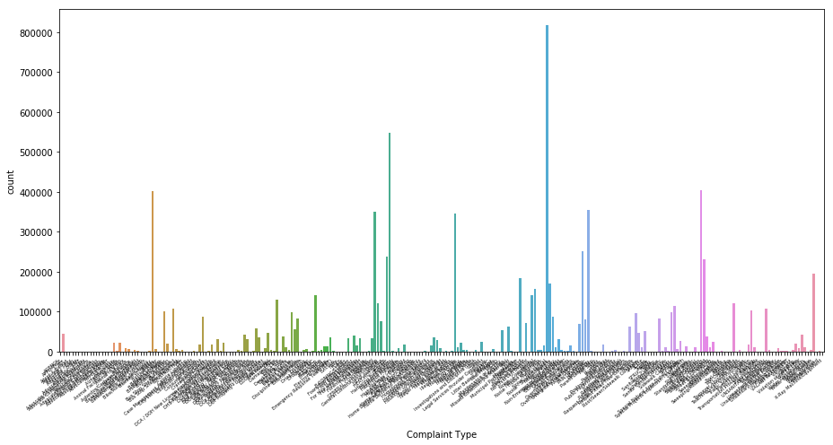

```python
plt.rcParams["figure.figsize"] = (13, 7)
ax=sns.countplot(x='Complaint Type',data=df)
ax.set_xticklabels(ax.get_xticklabels(),fontsize=5, rotation=40, ha="right")
plt.tight_layout()
plt.show()

#g = sns.factorplot("Complaint Type", data=df, aspect=1.5, kind="count", color="b")
#g.set_xticklabels(rotation=30)
```

```python
df.groupby(["Borough"])["Complaint Type"].value_counts()
```

```
Borough      Complaint Type
BRONX        Noise - Residential                     406742
             HEAT/HOT WATER                          366819
             HEATING                                 195284
             Street Light Condition                  173246
             PLUMBING                                172113
             Blocked Driveway                        136602
             UNSANITARY CONDITION                    124160
             PAINT/PLASTER                           108647
             GENERAL CONSTRUCTION                    107868
             Water System                            105971
             Street Condition                        104130
             Illegal Parking                          84808
             PAINT - PLASTER                          79422
             Noise - Street/Sidewalk                  72133
             ELECTRIC                                 70628
             DOOR/WINDOW                              61511
             WATER LEAK                               56988
             Traffic Signal Condition                 52334
             Rodent                                   50926
             NONCONST                                 50599
             Dirty Conditions                         46717
             General Construction/Plumbing            42790
             FLOORING/STAIRS                          41837
             GENERAL                                  37377
             Sanitation Condition                     34597
             Sewer                                    34332
             Noise - Vehicle                          30776
             Graffiti                                 30612
             APPLIANCE                                30290
             Building/Use                             29464
                                                      ...
Unspecified  Illegal Animal Kept as Pet                   3
             DOF Property - RPIE Issue                    2
             FCST                                         2
             General Construction/Plumbing                2
             Graffiti                                     2
             Industrial Waste                             2
             NORC Complaint                               2
             Plant                                        2
```

[output cut: 8 more lines]

```
             Broken Muni Meter                            1
             Calorie Labeling                             1
             City Vehicle Placard Complaint               1
             Electrical                                   1
             HEAT/HOT WATER                               1
             Illegal Fireworks                            1
             Meals Home Delivery Required                 1
             OEM Disabled Vehicle                         1
             Posting Advertisement                        1
             Public Toilet                                1
             Recycling Enforcement                        1
             Taxpayer Advocate Inquiry                    1
             Unsanitary Animal Facility                   1
             Urinating in Public                          1
Name: Complaint Type, Length: 1376, dtype: int64
```

```python
pd.set_option('display.max_rows', 500)
df["Complaint Type"].value_counts()
# df["Complaint Type"].unique()
```

```
Noise - Residential                          1631845
HEAT/HOT WATER                               1127466
Street Condition                              903505
HEATING                                       887869
Street Light Condition                        865931
Blocked Driveway                              819485
Illegal Parking                               763796
PLUMBING                                      688828
Water System                                  600567
GENERAL CONSTRUCTION                          500863
Noise                                         440557
UNSANITARY CONDITION                          411395
Traffic Signal Condition                      406231
Noise - Street/Sidewalk                       383623
General Construction/Plumbing                 376668
PAINT - PLASTER                               361258
Sewer                                         337359
PAINT/PLASTER                                 327071
Dirty Conditions                              324233
Noise - Commercial                            319810
ELECTRIC                                      296281
Sanitation Condition                          289054
Request Large Bulky Item Collection           276420
Damaged Tree                                  267985
NONCONST                                      260890
Building/Use                                  253527
Rodent                                        247277
Missed Collection (All Materials)             230226
Sidewalk Condition                            216525
Derelict Vehicle                              200779
DOOR/WINDOW                                   190524
Derelict Vehicles                             183170
Noise - Vehicle                               181599
WATER LEAK                                    177766
Broken Muni Meter                             172119
Taxi Complaint                                160603
Consumer Complaint                            158436
Graffiti                                      155560
New Tree Request                              141291
GENERAL                                       138987
```

[output cut: 224 more lines]

```
Trapping Pigeon                                    2
Homebound Evacuation 4                             2
Meals Home Delivery Required                       1
LEAD                                               1
Unspecified                                        1
Advocate-Foreclosure                               1
Illegal Animal - Sold/Kept                         1
Unlicensed Dog                                     1
Asbestos/Garbage Nuisance                          1
CST                                                1
SG-99                                              1
MOLD                                               1
Injured Wildlife                                   1
DOF Literature Request                             1
Name: Complaint Type, dtype: int64
```

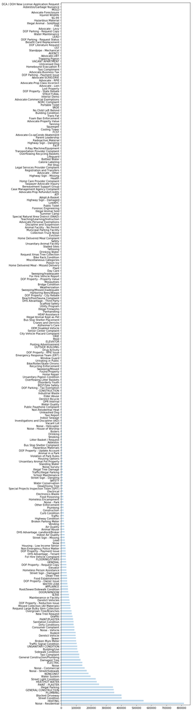

```python
#plt.rcParams["figure.figsize"] = (10, 20)
df['Complaint Type'].value_counts().plot(kind='barh',alpha=0.3, figsize=(9,50))
plt.show()
```

```python
df.groupby(["Complaint Type"])["City"].value_counts()
```

```
Complaint Type           City
AGENCY                   BRONX                      3
                         NEW YORK                   2
                         Arverne                    1
                         BROOKLYN                   1
                         Jamaica                    1
APPLIANCE                BRONX                  35572
                         BROOKLYN               34900
                         NEW YORK               19014
                         STATEN ISLAND           2523
                         Jamaica                 1327
                         JAMAICA                  810
                         Far Rockaway             805
                         Flushing                 641
                         Astoria                  602
                         Ridgewood                494
                         Corona                   452
                         FAR ROCKAWAY             401
                         Woodside                 326
                         South Richmond Hill      305
                         Elmhurst                 293
                         Jackson Heights          288
                         ASTORIA                  261
                         Queens Village           256
                         FLUSHING                 241
                         RIDGEWOOD                234
                         Saint Albans             223
                         ELMHURST                 217
                         Arverne                  210
                         Ozone Park               197
                         Springfield Gardens      191
                                                ...
Window Guard             BELLEROSE                  3
                         FOREST HILLS               3
                         HOLLIS                     3
                         MASPETH                    3
                         SOUTH OZONE PARK           3
                         WHITESTONE                 3
                         KEW GARDENS                2
                         LITTLE NECK                2
```

[output cut: 8 more lines]

```
                         ASTORIA                    4
                         FLUSHING                   4
                         HOWARD BEACH               3
                         REGO PARK                  3
                         FOREST HILLS               2
                         LONG ISLAND CITY           2
                         RIDGEWOOD                  2
                         ELMHURST                   1
                         FRESH MEADOWS              1
                         JACKSON HEIGHTS            1
                         JAMAICA                    1
                         KEW GARDENS                1
                         SOUTH RICHMOND HILL        1
                         WOODSIDE                   1
Name: City, Length: 14784, dtype: int64
```

#### What is the total number of General Construction complaints that came to the Department of Housing Preservation and Development of New York City?

```python
# df[df["Complaint Type"]=="GENERAL CONSTRUCTION"].count()
df[df["Complaint Type"]=="GENERAL CONSTRUCTION"]["Unique Key"].count()
```

```
349883
```

```python
df.groupby(["Complaint Type"]).size().reset_index(name='counts')
```

|  | Complaint Type | counts |
| --- | --- | --- |
| 0 | AGENCY | 1 |
| 1 | APPLIANCE | 45786 |
| 2 | ATF | 141 |
| 3 | Adopt-A-Basket | 158 |
| 4 | Advocate - Levy | 0 |
| 5 | Advocate - Lien | 4 |
| 6 | Advocate - Other | 111 |
| 7 | Advocate - RPIE | 3 |
| 8 | Advocate-Business Tax | 2 |
| 9 | Advocate-Co-opCondo Abatement | 33 |
| 10 | Advocate-Commercial Exemptions | 9 |
| 11 | Advocate-Foreclosure | 0 |
| 12 | Advocate-Personal Exemptions | 304 |
| 13 | Advocate-Prop Class Incorrect | 3 |
| 14 | Advocate-Prop Refunds/Credits | 139 |
| 15 | Advocate-Property Value | 16 |
| 16 | Advocate-SCRIE/DRIE | 3 |
| 17 | Advocate-UBT | 1 |
| 18 | Air Quality | 21363 |
| 19 | Alzheimer's Care | 1425 |
| 20 | Animal Abuse | 22289 |
| 21 | Animal Facility - No Permit | 363 |
| 22 | Animal in a Park | 8761 |
| 23 | Asbestos | 6976 |
| 24 | Asbestos/Garbage Nuisance | 0 |
| 25 | BEST/Site Safety | 3227 |
| 26 | Beach/Pool/Sauna Complaint | 939 |
| 27 | Benefit Card Replacement | 1 |
| 28 | Bereavement Support Group | 131 |
| 29 | Bike Rack Condition | 583 |

[output cut: 228 more lines]

```python
#df[df['Incident Zip'].notnull() & (df['Complaint Type']=='GENERAL CONSTRUCTION')].head()
```

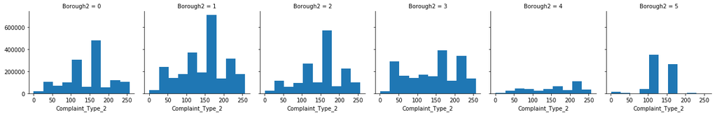

```python
g = sns.FacetGrid(data=df2,col='Borough2')
g.map(plt.hist,'Complaint_Type_2')
```

```python
complaints=df.groupby(["Complaint Type","Incident Zip"])["Borough"].describe()
complaints.columns
complaints.sort_values(by="count",ascending=False)
```

| Complaint Type | Incident Zip | count | unique | top | freq |
| --- | --- | --- | --- | --- | --- |
| HEAT/HOT WATER | 11226.0 | 29398 | 1 | BROOKLYN | 29398 |
|  | 10458.0 | 28064 | 1 | BRONX | 28064 |
|  | 10467.0 | 27276 | 1 | BRONX | 27276 |
|  | 10468.0 | 24310 | 1 | BRONX | 24310 |
|  | 10453.0 | 24035 | 1 | BRONX | 24035 |
|  | 10452.0 | 19998 | 1 | BRONX | 19998 |
| Noise - Residential | 11226 | 19617 | 1 | BROOKLYN | 19617 |
|  | 10467.0 | 19576 | 2 | BRONX | 19572 |
|  | 10467 | 19307 | 1 | BRONX | 19307 |
| HEAT/HOT WATER | 10031.0 | 18956 | 1 | MANHATTAN | 18956 |
|  | 10457.0 | 18954 | 1 | BRONX | 18954 |
|  | 10456.0 | 18505 | 1 | BRONX | 18505 |
|  | 10462.0 | 18278 | 1 | BRONX | 18278 |
| Noise - Residential | 11226.0 | 18149 | 2 | BROOKLYN | 18147 |
| HEAT/HOT WATER | 11225.0 | 17804 | 1 | BROOKLYN | 17804 |
| HEATING | 10467 | 17437 | 2 | BRONX | 10376 |
|  | 11226 | 17247 | 2 | BROOKLYN | 9726 |
| Noise - Residential | 10468 | 16977 | 1 | BRONX | 16977 |
|  | 10468.0 | 16956 | 2 | BRONX | 16954 |
| HEATING | 10458 | 16755 | 2 | BRONX | 10034 |
| HEAT/HOT WATER | 11213.0 | 16634 | 1 | BROOKLYN | 16634 |
|  | 10040.0 | 16558 | 1 | MANHATTAN | 16558 |
|  | 10472.0 | 15309 | 1 | BRONX | 15309 |
| Noise - Residential | 10458 | 15063 | 1 | BRONX | 15063 |
|  | 10031.0 | 15028 | 2 | MANHATTAN | 15026 |
| HEATING | 10468 | 14914 | 2 | BRONX | 8841 |
| Noise - Residential | 10031 | 14871 | 1 | MANHATTAN | 14871 |
| HEATING | 10453 | 14818 | 2 | BRONX | 8461 |
| Noise - Residential | 10458.0 | 14792 | 2 | BRONX | 14791 |
| PLUMBING | 11226 | 14691 | 2 | BROOKLYN | 10017 |
| ... | ... | ... | ... | ... | ... |
| Housing Options | 30083 | 1 | 1 | Unspecified | 1 |
|  | 30092 | 1 | 1 | Unspecified | 1 |
|  | 30135 | 1 | 1 | Unspecified | 1 |
|  | 30344 | 1 | 1 | Unspecified | 1 |
|  | 317707 | 1 | 1 | Unspecified | 1 |
|  | 32233 | 1 | 1 | Unspecified | 1 |
|  | 32668 | 1 | 1 | Unspecified | 1 |
|  | 32725 | 1 | 1 | Unspecified | 1 |
|  | 32801 | 1 | 1 | Unspecified | 1 |
|  | 32812 | 1 | 1 | Unspecified | 1 |
|  | 32905 | 1 | 1 | Unspecified | 1 |
|  | 33069 | 1 | 1 | Unspecified | 1 |
|  | 33139 | 1 | 1 | Unspecified | 1 |
|  | 33161 | 1 | 1 | Unspecified | 1 |
|  | 33162 | 1 | 1 | Unspecified | 1 |
|  | 33180 | 1 | 1 | Unspecified | 1 |
|  | 33311 | 1 | 1 | Unspecified | 1 |
|  | 33324 | 1 | 1 | Unspecified | 1 |
|  | 33442 | 1 | 1 | Unspecified | 1 |
|  | 33446 | 1 | 1 | Unspecified | 1 |
|  | 33480 | 1 | 1 | Unspecified | 1 |
|  | 34208-5336 | 1 | 1 | Unspecified | 1 |
|  | 34231 | 1 | 1 | Unspecified | 1 |
|  | 37660 | 1 | 1 | Unspecified | 1 |
|  | 40202 | 1 | 1 | Unspecified | 1 |
|  | 43612 | 1 | 1 | Unspecified | 1 |
|  | 45242 | 1 | 1 | Unspecified | 1 |
|  | 48043 | 1 | 1 | Unspecified | 1 |
|  | 48346 | 1 | 1 | Unspecified | 1 |
| X-Ray Machine/Equipment | 11435 | 1 | 1 | QUEENS | 1 |

67714 rows × 4 columns

#### For the Complaint Type that you selected, can you determine the total number of complaints at the Street level?

```python
df.groupby(["Complaint Type","Street Name"])["Unique Key"].count()
```

```
Complaint Type           Street Name
AGENCY                   61 STREET                    1
                         ANDREWS AVENUE SOUTH         1
                         BEACH 56 PLACE               1
                         FIFTH AVENUE                 1
                         LOWELL STREET                1
                         SEDGWICK AVENUE              1
                         SUTPHIN BOULEVARD            1
                         WEST  146 STREET             1
                         WEST  148 STREET             1
APPLIANCE                1 AVENUE                   211
                         1 PLACE                      3
                         10 AVENUE                  122
                         10 STREET                   11
                         100 AVENUE                   5
                         100 STREET                  10
                         101 AVENUE                  49
                         101 ROAD                     1
                         101 STREET                  25
                         102 AVENUE                  27
                         102 ROAD                     5
                         102 STREET                  46
                         103 AVENUE                  25
                         103 DRIVE                    1
                         103 ROAD                     8
                         103 STREET                  45
                         104 AVENUE                  16
                         104 STREET                  26
                         105 AVENUE                  43
                         105 STREET                  11
                         106 AVENUE                  28
                         106 ROAD                     2
                         106 STREET                   5
                         107 AVENUE                  35
                         107 STREET                  12
                         108 AVENUE                  16
                         108 DRIVE                    3
                         108 STREET                  48
                         109 AVENUE                  49
                         109 DRIVE                    3
```

[output cut: 448 more lines]

```
                         SECOND AVENUE                1
                         TELEPORT DRIVE               1
                         TENTH AVENUE                 1
                         VICTORY BOULEVARD            1
                         WEBSTER AVENUE               1
                         WEST 14 STREET               1
                         WEST 17 STREET               1
                         WEST 57 STREET               1
                         WEST 60 STREET               1
                         WEST 72 STREET               2
                         WEST END AVENUE              1
                         WILLIAMS AVENUE              1
                         WOODHAVEN BOULEVARD          2
                         YORK AVENUE                  1
Name: Unique Key, Length: 514343, dtype: int64
```

```python
df.groupby(["Complaint Type","Street Name"])["Unique Key"].sum()
```

```
Complaint Type           Street Name
AGENCY                   SEDGWICK AVENUE              36965304
APPLIANCE                1 AVENUE                   2140699426
                         10 AVENUE                  1772919562
                         10 STREET                   130571135
                         100 AVENUE                   41953351
                         100 STREET                  174457672
                         101 AVENUE                  464444201
                         101 ROAD                     16789879
                         101 STREET                  271174374
                         102 AVENUE                  263368745
                         102 ROAD                     24792734
                         102 STREET                  471380023
                         103 AVENUE                  145102569
                         103 DRIVE                    39733180
                         103 ROAD                     84106008
                         103 STREET                  745435026
                         104 AVENUE                  180450244
                         104 STREET                  315692500
                         105 AVENUE                  308232314
                         105 STREET                   62206433
                         106 AVENUE                  341192835
                         106 ROAD                     36126013
                         106 STREET                   77203614
                         107 AVENUE                  477457477
                         107 STREET                  199347307
                         108 AVENUE                  217951965
                         108 DRIVE                    36305044
                         108 STREET                  553530898
                         109 AVENUE                  717791074
                         109 STREET                  264043198
                         11 AVENUE                   151877526
                         110 AVENUE                  276563198
                         110 STREET                  381257951
                         111 AVENUE                  504507369
                         111 STREET                  582273685
                         112 AVENUE                   51320601
                         112 ROAD                    115312589
                         112 STREET                  210150598
                         113 AVENUE                   83152064
```

[output cut: 448 more lines]

```
                         RALPH PLACE                  25000411
                         RIDER AVENUE                 20850712
                         SECOND AVENUE                24408659
                         TELEPORT DRIVE               33996144
                         TENTH AVENUE                 19848275
                         VICTORY BOULEVARD            25054310
                         WEST 14 STREET               35602380
                         WEST 17 STREET               19847004
                         WEST 57 STREET               25072292
                         WEST 60 STREET               24144321
                         WEST 72 STREET               42358168
                         WEST END AVENUE              37229519
                         WILLIAMS AVENUE              28228081
                         YORK AVENUE                  32250440
Name: Unique Key, Length: 377263, dtype: int64
```

```python
#SEDGWICK AVENUE
df[df["Street Name"]=="SEDGWICK AVENUE"]["Complaint Type"].value_counts()
```

```
HEATING                                      2346
HEAT/HOT WATER                               1298
PLUMBING                                     1273
GENERAL CONSTRUCTION                         1181
Noise - Residential                          1059
PAINT - PLASTER                               802
NONCONST                                      538
Illegal Parking                               442
UNSANITARY CONDITION                          389
Blocked Driveway                              388
ELECTRIC                                      375
PAINT/PLASTER                                 280
DOOR/WINDOW                                   223
Street Condition                              195
Elevator                                      169
Water System                                  157
APPLIANCE                                     145
WATER LEAK                                    143
FLOORING/STAIRS                               140
GENERAL                                       117
Noise - Vehicle                               113
Rodent                                         97
Noise - Street/Sidewalk                        77
General Construction/Plumbing                  65
Noise                                          53
Street Light Condition                         46
Damaged Tree                                   42
Graffiti                                       37
Sidewalk Condition                             37
New Tree Request                               33
Dirty Conditions                               32
SAFETY                                         29
Indoor Air Quality                             27
Sanitation Condition                           24
Building/Use                                   24
Sewer                                          24
Taxi Complaint                                 22
Animal Abuse                                   21
Overgrown Tree/Branches                        21
Noise - Park                                   19
```

[output cut: 204 more lines]

```
Municipal Parking Facility                      0
Mold                                            0
MOLD                                            0
LinkNYC                                         0
Illegal Animal Sold                             0
Lifeguard                                       0
Legal Services Provider Complaint               0
LEAD                                            0
Investigations and Discipline (IAD)             0
Interior Demo                                   0
Injured Wildlife                                0
Indoor Sewage                                   0
Illegal Fireworks                               0
Housing Options                                 0
Name: Complaint Type, dtype: int64
```

```python
#SEDGWICK AVENUE
df[df["Street Name"]=="SEDGWICK AVENUE"]["Unique Key"].count()
```

```
12880
```

#### Which approach do you think can be used to find the total number of complaints for an address?

```python
df.groupby(["Complaint Type","Incident Zip","Incident Address"])["Unique Key"].count()
```

```
Complaint Type           Incident Zip  Incident Address
AGENCY                   10468         2297 SEDGWICK AVENUE               1
APPLIANCE                10001         1230 BROADWAY                      2
                                       126 WEST 25 STREET                 2
                                       146 WEST 28 STREET                 1
                                       15 WEST   29 STREET                1
                                       154 WEST   27 STREET               1
                                       229 WEST 26 STREET                 2
                                       237 9 AVENUE                       1
                                       245 WEST   25 STREET               1
                                       251 WEST 26 STREET                 1
                                       259 WEST 29 STREET                 1
                                       266 WEST   25 STREET               1
                                       284 5 AVENUE                       2
                                       299 10 AVENUE                      1
```

[output cut: 488 more lines]

```python
df[df["Incident Address"]=="1230 BROADWAY"]["Unique Key"].count()
```

```
212
```

```python
df[df["Incident Address"]=="1230 BROADWAY"]["Complaint Type"].value_counts()
```

```
GENERAL CONSTRUCTION                         47
PLUMBING                                     39
NONCONST                                     26
PAINT - PLASTER                              24
UNSANITARY CONDITION                         20
HEATING                                      18
ELECTRIC                                     14
HEAT/HOT WATER                                4
FLOORING/STAIRS                               4
DOOR/WINDOW                                   4
PAINT/PLASTER                                 3
ELEVATOR                                      3
SAFETY                                        2
APPLIANCE                                     2
WATER LEAK                                    1
Consumer Complaint                            1
Drug Activity                                 0
Drinking Water                                0
Derelict Vehicles                             0
Elder Abuse                                   0
Drinking                                      0
Disorderly Youth                              0
Discipline and Suspension                     0
Dirty Conditions                              0
X-Ray Machine/Equipment                       0
Derelict Vehicle                              0
Derelict Bicycle                              0
Dead/Dying Tree                               0
Electronics Waste                             0
Dead Tree                                     0
Day Care                                      0
Damaged Tree                                  0
DRIE                                          0
DPR Internal                                  0
DOF Property - Update Account                 0
DOF Property - State Rebate                   0
DOF Property - Request Copy                   0
Electrical                                    0
FATF                                          0
Elevator                                      0
```

[output cut: 204 more lines]

```
Other Enforcement                             0
OUTSIDE BUILDING                              0
OEM Disabled Vehicle                          0
Non-Residential Heat                          0
Non-Emergency Police Matter                   0
Noise Survey                                  0
Noise - Vehicle                               0
Noise - Street/Sidewalk                       0
Noise - Residential                           0
Noise - Park                                  0
Noise - House of Worship                      0
Noise - Helicopter                            0
Noise - Commercial                            0
AGENCY                                        0
Name: Complaint Type, dtype: int64
```

#### Which is the Complaint Type that the Department of Housing Preservation and Development of New York City should address first considering complaints created till 31st Dec 2018 ?

```python
#df["Year"]=df["Year"].astype(int)
#(df["Year"].loc["2010":"2018"]).value_counts()
by2019=df[df["Year"]==2019]
pd.set_option('display.max_rows', 500)
by2019.groupby(by2019["Complaint Type"])["Unique Key"].count()

# by 2019 grouped_by only
```

[output not shown]

[output cut: 205 more lines]

```
Urinating in Public                             32
Utility Program                                  0
VACANT APARTMENT                                 0
Vacant Lot                                     100
Vending                                        225
Violation of Park Rules                         97
WATER LEAK                                    2949
Water Conservation                             393
Water Maintenance                                0
Water Quality                                  111
Water System                                  4111
Weatherization                                   0
Window Guard                                     3
X-Ray Machine/Equipment                          0
Name: Unique Key, dtype: int64
```

```python
df.groupby(df["Year"])["Complaint Type"].value_counts()
```

```
Year  Complaint Type
2010  HEATING                                 166669
      GENERAL CONSTRUCTION                    102737
      Noise - Residential                      92411
      PLUMBING                                 90588
      Street Condition                         80527
      PAINT - PLASTER                          76015
      NONCONST                                 56548
      Street Light Condition                   52013
      Blocked Driveway                         40479
      General Construction/Plumbing            36670
      ELECTRIC                                 31509
      Damaged Tree                             29252
      Building/Use                             23446
      Traffic Signal Condition                 22954
      DHS Advantage - Tenant                   18286
      Taxi Complaint                           17996
      Rodent                                   17076
      Noise - Commercial                       16546
      Graffiti                                 16238
      Illegal Parking                          16037
      Noise - Street/Sidewalk                  14716
      Consumer Complaint                       14120
      Sidewalk Condition                       13743
      APPLIANCE                                12101
      Derelict Vehicle                         11779
      Overgrown Tree/Branches                  11627
      Traffic/Illegal Parking                  11620
      DHS Advantage -Landlord/Broker           11276
      Noise - Vehicle                          10986
      Broken Muni Meter                        10603
                                               ...
2019  FATF                                         9
      Foam Ban Enforcement                         9
      Posting Advertisement                        8
      Taxpayer Advocate Inquiry                    8
      Home Delivered Meal Complaint                6
      Pet Shop                                     6
      Plant                                        6
      Special Natural Area District (SNAD)         6
```

[output cut: 8 more lines]

```
      Illegal Animal Sold                          2
      Illegal Fireworks                            2
      Lifeguard                                    2
      Advocate - RPIE                              1
      Advocate-Business Tax                        1
      Advocate-Co-opCondo Abatement                1
      Bereavement Support Group                    1
      Case Management Agency Complaint             1
      Legal Services Provider Complaint            1
      Miscellaneous Categories                     1
      Mosquitoes                                   1
      Municipal Parking Facility                   1
      Poison Ivy                                   1
      Radioactive Material                         1
Name: Complaint Type, Length: 1805, dtype: int64
```

## Question 2 - What Areas Should the Agency Focus On?

#### Should the Department of Housing Preservation and Development of New York City focus on any particular set of boroughs, ZIP codes, or street (where the complaints are severe) for the specific type of complaints you identified in response to Question 1?

```python
df["Complaint Type"].unique()
```

```
[DOF Parking - Tax Exemption, Electronics Waste, Illegal Parking, HEAT/HOT WATER, UNSANITARY CONDITION, ..., Unlicensed Dog, Standpipe - Mechanical, DOF Literature Request, Benefit Card Replacement, STRUCTURAL]
Length: 246
Categories (246, object): [DOF Parking - Tax Exemption, Electronics Waste, Illegal Parking, HEAT/HOT WATER, ..., Standpipe - Mechanical, DOF Literature Request, Benefit Card Replacement, STRUCTURAL]
```

```python
q2=pd.DataFrame(df.groupby(["Complaint Type","Borough","Incident Zip", "Street Name"])["Descriptor"].count())
# q2=pd.DataFrame(df.groupby(["complaint_type","borough", "street_name"])["incident_zip"].count())
(q2.sort_values(by=['Descriptor'],ascending=False)).head()
```

| Complaint Type | Borough | Incident Zip | Street Name | Descriptor |
| --- | --- | --- | --- | --- |
| HEATING | MANHATTAN | 10040 | ARDEN STREET | 4793 |
| Noise - Residential | BROOKLYN | 11205 | MONUMENT WALK | 3157 |
|  |  | 11226 | EAST 21 STREET | 2917 |
| HEATING | BRONX | 10463 | BAILEY AVENUE | 2902 |
| Noise - Residential | BRONX | 10468 | DAVIDSON AVENUE | 2441 |

```python
df2.columns
```

[output not shown]

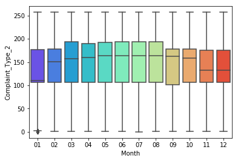

```python
sns.boxplot(x='Month',y='Complaint_Type_2',data=df2,palette='rainbow')
```

```python
# sns.stripplot(x="Month", y="Complaint_Type_2", data=df2,jitter=True,hue='Borough2',palette='Set1',split=True)
```

#### Which approach do you think can be used to find the total number of complaints for an address?

```python
df[df["Incident Address"]=="230 PARK AVENUE"]["Complaint Type"].count()
```

```
67
```

```python
df[df["Incident Address"]=="230 PARK AVENUE"]["Complaint Type"].value_counts()
```

```
Homeless Person Assistance                   36
Taxi Complaint                                6
Street Condition                              3
Homeless Encampment                           2
Illegal Parking                               2
General Construction/Plumbing                 2
For Hire Vehicle Complaint                    2
Traffic                                       2
Broken Muni Meter                             2
Blocked Driveway                              1
Street Sign - Damaged                         1
X-Ray Machine/Equipment                       1
Sewer                                         1
Consumer Complaint                            1
Noise                                         1
Indoor Air Quality                            1
Food Establishment                            1
Recycling Enforcement                         1
Water System                                  1
Advocate-SCRIE/DRIE                           0
Drinking                                      0
FATF                                          0
Eviction                                      0
Emergency Response Team (ERT)                 0
Elevator                                      0
Electronics Waste                             0
Advocate - RPIE                               0
Electrical                                    0
Elder Abuse                                   0
ELEVATOR                                      0
ELECTRIC                                      0
Drug Activity                                 0
Drinking Water                                0
Disorderly Youth                              0
FHE                                           0
Discipline and Suspension                     0
Dirty Conditions                              0
Derelict Vehicles                             0
Derelict Vehicle                              0
Derelict Bicycle                              0
```

[output cut: 204 more lines]

```
Noise - Commercial                            0
Other Enforcement                             0
OUTSIDE BUILDING                              0
OEM Disabled Vehicle                          0
Non-Residential Heat                          0
Non-Emergency Police Matter                   0
Noise Survey                                  0
Noise - Vehicle                               0
Noise - Street/Sidewalk                       0
Noise - Residential                           0
Noise - Park                                  0
Noise - House of Worship                      0
Noise - Helicopter                            0
AGENCY                                        0
Name: Complaint Type, dtype: int64
```

```python
pd.DataFrame(df.groupby(["Complaint Type","Incident Address","City","Location Type"])["Descriptor"].count())
```

| Complaint Type | Incident Address | City | Location Type | Descriptor |
| --- | --- | --- | --- | --- |
| AGENCY | 1038 LOWELL STREET | BRONX | RESIDENTIAL BUILDING | 1 |
|  | 109-29 SUTPHIN BOULEVARD | Jamaica | RESIDENTIAL BUILDING | 1 |
|  | 141 BEACH 56 PLACE | Arverne | RESIDENTIAL BUILDING | 1 |
|  | 1725 61 STREET | BROOKLYN | RESIDENTIAL BUILDING | 1 |
|  | 1890 ANDREWS AVENUE SOUTH | BRONX | RESIDENTIAL BUILDING | 1 |
|  | 203 WEST 148 STREET | NEW YORK | RESIDENTIAL BUILDING | 1 |
|  | 2297 SEDGWICK AVENUE | BRONX | RESIDENTIAL BUILDING | 1 |
|  | 454 WEST 146 STREET | NEW YORK | RESIDENTIAL BUILDING | 1 |
| APPLIANCE | 1 74 STREET | BROOKLYN | RESIDENTIAL BUILDING | 2 |
|  | 1 ADRIAN AVENUE | NEW YORK | RESIDENTIAL BUILDING | 7 |
|  | 1 BOGARDUS PLACE | NEW YORK | RESIDENTIAL BUILDING | 6 |
|  | 1 BRIGHTON 10 COURT | BROOKLYN | RESIDENTIAL BUILDING | 1 |
|  | 1 BROADWAY TERRACE | NEW YORK | RESIDENTIAL BUILDING | 1 |
|  | 1 CABRINI BOULEVARD | NEW YORK | RESIDENTIAL BUILDING | 1 |
|  | 1 CHESTER COURT | BROOKLYN | RESIDENTIAL BUILDING | 1 |
|  | 1 CHESTNUT STREET | STATEN ISLAND | RESIDENTIAL BUILDING | 3 |
|  | 1 EAST 35 STREET | NEW YORK | RESIDENTIAL BUILDING | 4 |
|  | 1 EAST 124 STREET | NEW YORK | RESIDENTIAL BUILDING | 1 |
|  | 1 EAST 198 STREET | BRONX | RESIDENTIAL BUILDING | 2 |
|  | 1 EAST 107 STREET | NEW YORK | RESIDENTIAL BUILDING | 2 |
|  | 1 EAST 124 STREET | NEW YORK | RESIDENTIAL BUILDING | 1 |
|  | 1 EAST 198 STREET | BRONX | RESIDENTIAL BUILDING | 4 |
|  | 1 EDGAR TERRACE | STATEN ISLAND | RESIDENTIAL BUILDING | 1 |
|  | 1 ELTON STREET | BROOKLYN | RESIDENTIAL BUILDING | 8 |
|  | 1 FAIRVIEW PLACE | BROOKLYN | RESIDENTIAL BUILDING | 2 |
|  | 1 JACOBUS PLACE | NEW YORK | RESIDENTIAL BUILDING | 18 |
|  | 1 KENILWORTH PLACE | BROOKLYN | RESIDENTIAL BUILDING | 2 |
|  | 1 MAC DONOUGH STREET | BROOKLYN | RESIDENTIAL BUILDING | 3 |
|  | 1 MARBLE HILL AVENUE | NEW YORK | RESIDENTIAL BUILDING | 7 |
|  | 1 MORNINGSIDE DRIVE | NEW YORK | RESIDENTIAL BUILDING | 5 |
| ... | ... | ... | ... | ... |
| X-Ray Machine/Equipment | 446 FIRST AVENUE | NEW YORK | Hospital | 1 |
|  | 462 1 AVENUE | NEW YORK | Hospital | 1 |
|  | 4802 TENTH AVENUE | BROOKLYN | Hospital | 1 |
|  | 4849 ARTHUR KILL ROAD | STATEN ISLAND | Doctor's Office | 2 |
|  | 500 BERGEN AVENUE | BRONX | Dentist's Office | 1 |
|  | 506 6 STREET | BROOKLYN | Hospital | 1 |
|  | 518 GRAND STREET | BROOKLYN | Veterinarian's Office | 1 |
|  | 535 8 AVENUE | NEW YORK | Doctor's Office | 1 |
|  | 544 PARK AVENUE | BROOKLYN | Other (Explain Below) | 1 |
|  | 57 WEST 57 STREET | NEW YORK | Dentist's Office | 1 |
|  | 59-14 COOPER AVENUE | RIDGEWOOD | Other (Explain Below) | 1 |
|  | 62-43 WOODHAVEN BOULEVARD | REGO PARK | Doctor's Office | 1 |
|  |  |  | Other (Explain Below) | 1 |
|  | 6700 3 AVENUE | BROOKLYN | Other (Explain Below) | 1 |
|  | 6801 21 AVENUE | BROOKLYN | Other (Explain Below) | 1 |
|  | 681 CLARKSON AVENUE | BROOKLYN | Hospital | 1 |
|  | 707 EAST 242 STREET | BRONX | Other (Explain Below) | 1 |
|  | 727 7 AVENUE | NEW YORK | Other (Explain Below) | 1 |
|  | 76-79 172 STREET | FRESH MEADOWS | Doctor's Office | 1 |
|  | 7708 5 AVENUE | BROOKLYN | Dentist's Office | 1 |
|  | 78-57 78 STREET | RIDGEWOOD | Other (Explain Below) | 1 |
|  | 80 NORTH 1 STREET | BROOKLYN | Veterinarian's Office | 1 |
|  | 800 SECOND AVENUE | NEW YORK | Doctor's Office | 1 |
|  | 80N 1 STREET | BROOKLYN | Veterinarian's Office | 1 |
|  | 85-15 126 STREET | KEW GARDENS | Doctor's Office | 1 |
|  | 9 BOND STREET | BROOKLYN | Other (Explain Below) | 1 |
|  | 9201 FOURTH AVENUE | BROOKLYN | Doctor's Office | 1 |
|  | 94-11 65 ROAD | REGO PARK | Doctor's Office | 1 |
|  | 94-31 60 AVENUE | ELMHURST | Doctor's Office | 1 |
|  | 955 5 AVENUE | NEW YORK | Doctor's Office | 1 |

3872009 rows × 1 columns

#### where homelessness is a problem?

```python
# Homeless Person Assistance
df[df["Complaint Type"]=="Homeless Person Assistance"]["Incident Address"].value_counts().head()
```

```
1841 BROADWAY         178
81 EAST 125 STREET     97
650 5 AVENUE           82
BROADWAY               78
530 5 AVENUE           78
Name: Incident Address, dtype: int64
```

## Question 3 - What Is the Relationship between Housing Characteristics and Complaints?

#### Does the Complaint Type that you identified in response to Question 1 have an obvious relationship with any particular characteristic or characteristic of the Houses?

```python
path=r'C:\Users\tuncay\OneDrive\Coding\IBM\capstone'
allFiles = glob.glob(path + "/*.csv")
frame = pd.DataFrame()
list_ = []
for file_ in allFiles:
    br = pd.read_csv(file_,index_col=None, header=0)
    list_.append(br)
boroughs = pd.concat(list_)
```

```python
# boroughs.head()
```

```python
#boroughs.info()
```

```python
#boroughs.isnull().sum()
```

```python
boroughs2=boroughs.dropna(axis=1)
```

```python
#boroughs2.isnull().sum()
```

```python
#boroughs2.info()
```

```python
drop_columns=["Borough","Version"]
boroughs2.drop(drop_columns, axis=1, inplace=True)
```

```python
boroughs3=boroughs.fillna(0)
```

```python
#boroughs3.isnull().sum(),boroughs3.info()
boroughs4=boroughs3._get_numeric_data()
```

```python
#boroughs2["Borough"]=df["Borough"].astype("category")
#boroughs2["Borough2"]=df["Borough"].cat.codes

#boroughs4.info()
```

```python
# df["Borough"].unique(),boroughs["Borough"].unique(),boroughs3["Borough"].unique(),boroughs4["BoroCode"].unique()
```

```python
# boroughs4.head()
```

```python
# df2.columns,boroughs4.columns
```

```python
boroughs4['ZipCode'] = boroughs4['ZipCode'].astype(str)
boroughs4["ZipCode"]=boroughs4['ZipCode'].str.extract(r'\b(\d{5})\b', expand=False)
boroughs4 = boroughs4.dropna(subset=['ZipCode'])
#boroughs4['ZipCode'] = boroughs4['ZipCode'].astype(int)
#list(boroughs4["ZipCode"].unique())
```

```python
# merged_df2_borough4=pd.merge(df2, boroughs4, left_on="Incident_Zip3", right_on="ZipCode")

# MEMORY ERROR !!!!!
```

```python
boroughs.groupby(["BldgClass","ZipCode","PolicePrct"])["LotArea"].mean().sort_values(ascending=False).head(10)
```

```
BldgClass  ZipCode  PolicePrct
T1         11430.0  113.0         2.147557e+08
Q1         10023.0  22.0          3.659000e+07
Q5         10314.0  122.0         3.185000e+07
Q1         10464.0  45.0          2.483549e+07
V1         10282.0  1.0           2.277234e+07
Q1         10467.0  50.0          2.225160e+07
P6         10306.0  122.0         1.790316e+07
Q1         11355.0  110.0         1.787000e+07
Y3         11370.0  114.0         1.782500e+07
Q0         11234.0  63.0          1.486545e+07
Name: LotArea, dtype: float64
```

```python
boroughs3.groupby(["BldgClass","ZipCode","PolicePrct"])["BldgArea"].mean().sort_values(ascending=False).head(10)
```

```
BldgClass  ZipCode  PolicePrct
Y4         11234.0  63.0          24000000.0
T1         11430.0  113.0         17095037.0
Q9         0.0      100.0         12252000.0
D4         10475.0  45.0           9540572.0
D7         10009.0  13.0           8942176.0
T2         11251.0  88.0           5865000.0
Y3         11370.0  114.0          5519372.0
T2         11220.0  72.0           5359400.0
D4         11005.0  105.0          3750565.0
           11434.0  113.0          3583913.0
Name: BldgArea, dtype: float64
```

```python
#boroughs[["BldgClass","ZipCode","PolicePrct"]].head()
# boroughs[boroughs["Borough"]=="QN"]
```

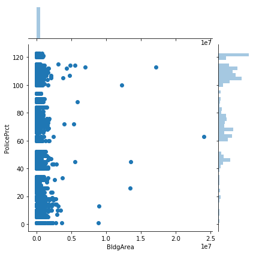

```python
sns.jointplot(x='BldgArea',y='PolicePrct',data=boroughs)
```

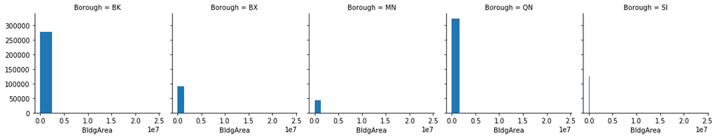

```python
g = sns.FacetGrid(data=boroughs,col='Borough')
g.map(plt.hist,'BldgArea')
```

```python
boroughs.groupby(["BldgClass","ZipCode"])["Address"].count().sort_values(ascending=False)

# A is for one family dwellings
# B is for two family dwellings

# certain zipcodes have higher A and B building_class, can be used as a comparison,
# such as what category of building_class has a higher correlation with what complaint_type.

# BUT DUE TO MEMORY ERROR, UNABLE TO DO SO.
```

```
BldgClass  ZipCode
A5         10312.0    6037
           10314.0    5360
B1         11236.0    4763
A5         10306.0    4663
B2         10314.0    4277
A1         11420.0    3752
           11412.0    3736
           10314.0    3714
A9         11234.0    3662
A5         11379.0    3381
           10305.0    3224
           11234.0    3166
B1         11234.0    3160
A1         11357.0    3115
           11229.0    3111
           10312.0    3088
B1         10469.0    3064
A1         10306.0    3015
           11358.0    2997
A2         10312.0    2960
A1         11428.0    2950
B2         10312.0    2928
A1         11413.0    2857
B1         11385.0    2836
A5         10309.0    2821
A1         11434.0    2815
           11429.0    2733
           11210.0    2699
A2         10306.0    2679
A5         11367.0    2671
                      ...
M3         11420.0       1
           11414.0       1
M2         11694.0       1
M3         11413.0       1
           10017.0       1
           10018.0       1
           10032.0       1
           10034.0       1
```

[output cut: 8 more lines]

```
A0         10011.0       1
M3         11004.0       1
           11102.0       1
           11105.0       1
           11106.0       1
           11212.0       1
           11225.0       1
           11232.0       1
           11354.0       1
           11358.0       1
           11364.0       1
           11366.0       1
           11411.0       1
U0         11220.0       0
Name: Address, Length: 15526, dtype: int64
```

#### Can you determine the age of the building from the PLUTO dataset?

```python
now=datetime.now()
boroughs["ageofbldg"]=now.year-boroughs["YearBuilt"]
change={2019:0}
boroughs=boroughs.replace(change)
boroughs.head()
```

|  | APPBBL | APPDate | Address | AreaSource | AssessLand | AssessTot | BBL | BldgArea | BldgClass | BldgDepth | ... | YearAlter2 | YearBuilt | ZMCode | ZipCode | ZoneDist1 | ZoneDist2 | ZoneDist3 | ZoneDist4 | ZoneMap | ageofbldg |
| --- | --- | --- | --- | --- | --- | --- | --- | --- | --- | --- | --- | --- | --- | --- | --- | --- | --- | --- | --- | --- | --- |
| 0 | 3.000010e+09 | 11/26/2013 | JOHN STREET | 4 | 1127700 | 1127700 | 3000010001 | 0 | V1 | 0.0 | ... | 0 | 0 | NaN | 11201.0 | M3-1 | M1-4/R8A | NaN | NaN | 12d | 0 |
| 1 | 0.000000e+00 | NaN | 10 JAY STREET | 2 | 834300 | 13780800 | 3000010050 | 163894 | O6 | 195.0 | ... | 2015 | 1920 | NaN | 11201.0 | M1-4/R8A | M3-1 | NaN | NaN | 12d | 99 |
| 2 | 3.000010e+09 | 03/04/2016 | 1 JOHN STREET | 7 | 389688 | 12347546 | 3000017501 | 102534 | RM | 0.0 | ... | 0 | 0 | NaN | 11201.0 | M3-1 | NaN | NaN | NaN | 12d | 0 |
| 3 | 0.000000e+00 | NaN | JAY STREET | 7 | 0 | 0 | 3000030001 | 0 | U4 | 0.0 | ... | 0 | 0 | NaN | 11201.0 | M3-1 | NaN | NaN | NaN | 12d | 0 |
| 4 | 0.000000e+00 | NaN | JAY STREET | 7 | 22050 | 22050 | 3000030005 | 0 | T2 | 0.0 | ... | 0 | 0 | NaN | 11201.0 | M3-1 | NaN | NaN | NaN | 12d | 0 |

5 rows × 90 columns

```python
boroughs.groupby(["Borough","ZipCode"])["ageofbldg"].mean()
# boroughs.groupby(["Borough","ZipCode"])["ageofbldg"].describe()
```

```
Borough  ZipCode
BK       11201.0     98.358174
         11203.0     85.781851
         11204.0     85.599799
         11205.0     80.312891
         11206.0     64.770646
         11207.0     71.997468
         11208.0     79.819703
         11209.0     92.890806
         11210.0     91.535293
         11211.0     87.718454
         11212.0     65.541148
         11213.0     95.605274
         11214.0     79.134385
         11215.0    101.101456
         11216.0     97.611483
         11217.0     95.305102
         11218.0     94.104257
         11219.0     79.784460
         11220.0     95.917229
         11221.0     84.689542
         11222.0     88.276831
         11223.0     82.635907
         11224.0     53.143058
         11225.0     94.026897
         11226.0     93.338831
         11228.0     88.305980
         11229.0     81.502026
         11230.0     88.161967
         11231.0     89.556466
         11232.0     86.968549
         11233.0     88.798306
         11234.0     73.795624
         11235.0     75.990558
         11236.0     65.949523
         11237.0     81.274069
         11238.0     86.267158
         11239.0     10.944563
         11241.0     91.000000
         11249.0     73.331856
```

[output cut: 163 more lines]

```
         11695.0     34.833333
         11697.0     41.538462
SI       10301.0     69.047340
         10302.0     74.057565
         10303.0     48.984136
         10304.0     55.964876
         10305.0     47.624493
         10306.0     48.252347
         10307.0     44.278222
         10308.0     48.557581
         10309.0     30.342333
         10310.0     74.292731
         10312.0     38.531229
         10314.0     49.119118
Name: ageofbldg, dtype: float64
```

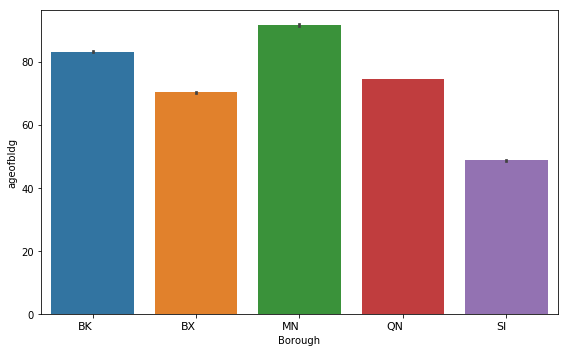

```python
plt.rcParams["figure.figsize"] = (8, 5)
ax=sns.barplot(x='Borough',y='ageofbldg',data=boroughs)
ax.set_xticklabels(ax.get_xticklabels(),fontsize=11, rotation=0, ha="right")
plt.tight_layout()
plt.show()
```

## Question 4 - Predict Complaint Types

#### Can a predictive model be built for future prediction of the possibility of complaints of the specific type that you identified in response to Question 1?

##### MultiLinear Model......THIS IS DONE JUST TO GIVE AN IDEA. IT WILL BE IMPROVED LATER ON.

```python
df2 = df2.rename(columns={'Agency Name2': 'Agency_Name2', 'Open Data Channel Type2': 'Open_Data_Channel_Type2',
                       "Park Facility Name2":"Park_Facility_Name2",'Park Borough2':'Park_Borough2',
                         'Complaint Type 2':'Complaint_Type_2',"Incident Zip3":"Incident_Zip3"})
```

```python
df2.head()
```

|  | Agency2 | Agency_Name2 | Complaint_Type_2 | Borough2 | Open_Data_Channel_Type2 | Park_Facility_Name2 | Park_Borough2 | Hour | Day | Month | Year | Incident_Zip3 |
| --- | --- | --- | --- | --- | --- | --- | --- | --- | --- | --- | --- | --- |
| 16384 | 7 | 99 | 60 | 2 | 3 | 3691 | 2 | 12 | 24 | 08 | 2018 | 10022 |
| 16385 | 12 | 63 | 90 | 4 | 3 | 3691 | 4 | 10 | 15 | 06 | 2018 | 10304 |
| 16386 | 12 | 63 | 90 | 1 | 3 | 3691 | 1 | 13 | 15 | 06 | 2018 | 11238 |
| 16387 | 18 | 91 | 133 | 1 | 0 | 3691 | 1 | 18 | 28 | 05 | 2018 | 11233 |
| 16388 | 15 | 60 | 110 | 0 | 0 | 3691 | 0 | 20 | 04 | 12 | 2018 | 10452 |

```python
df3.columns
```

[output not shown]

```python
# df2.corr()
df3=df2.drop("Park_Borough2",axis=1)
```

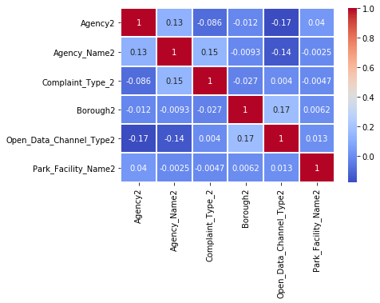

```python
sns.heatmap(df3.corr(),cmap='coolwarm',annot=True,linewidths=1)
```

```python
X=df2.loc[:,df3.columns != "Complaint_Type_2"]
y=df3["Complaint_Type_2"]
X_trainset, X_testset, y_trainset, y_testset = train_test_split(X, y, test_size=0.3, random_state=3)
```

```python
regr = linear_model.LinearRegression()
regr.fit(X, y)
```

```
LinearRegression(copy_X=True, fit_intercept=True, n_jobs=None,
         normalize=False)
```

```python
print('Intercept: \n', regr.intercept_)
print('Coefficients: \n', regr.coef_)
```

```
Intercept:
 -1295.0300975703278
Coefficients:
 [-1.86919912e+00  3.27362541e-02 -3.89031481e-01  1.96107047e+00
  1.65536388e-03 -3.89031481e-01  6.20224198e-02  8.65717877e-03
 -1.79802783e-01  7.20174584e-01]
```

```python
width = 12
height = 10
plt.figure(figsize=(width, height))
sns.regplot("Park_Facility_Name2", "Complaint_Type_2", df2)
plt.ylim(0,)
```

[output not shown]

```python
width = 12
height = 10
plt.figure(figsize=(width, height))
sns.residplot(df2['Park_Facility_Name2'], df2['Complaint_Type_2'])
plt.show()
```

[output not shown]

```python
Y_hat = regr.predict(X)
```

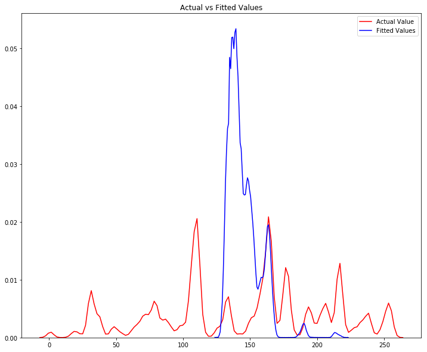

```python
plt.figure(figsize=(width, height))


ax1 = sns.distplot(df3['Complaint_Type_2'], hist=False, color="r", label="Actual Value")
sns.distplot(Y_hat, hist=False, color="b", label="Fitted Values" , ax=ax1)


plt.title('Actual vs Fitted Values')
plt.xlabel('')
plt.ylabel('')

plt.show()
plt.close()
```

```python
mse = mean_squared_error(df3['Complaint_Type_2'], Y_hat)
print('The mean square error (MSE) is: ', mse)
rmse=math.sqrt(mse)
print('The root mean square error (RMSE) is: ', rmse)
```

```
The mean square error (MSE) is:  3645.535113260836
The root mean square error (RMSE) is:  60.37826689514064
```

```python
#confusion_matrix(y, Y_hat)
```

```python
# smf
smf_model=smf.ols("Complaint_Type_2 ~ Agency2+Agency_Name2+Borough2+Open_Data_Channel_Type2+Park_Facility_Name2", df3).fit()
print(smf_model.summary())
```

[output not shown]

```python
#%%capture
#gather features
#features = "+".join(df2.columns - ["Complaint_Type_2"])

# get y and X dataframes based on this regression:
#y, X = dmatrices('Complaint_Type_2 ~' + features, df2, return_type='dataframe')
```

```python
#vif = pd.DataFrame()
#vif["VIF Factor"] = [variance_inflation_factor(X.values, i) for i in range(X.shape[1])]
#vif["features"] = X.columns
#vif.round(1)
```

##### Decision tree

```python
dtree = DecisionTreeClassifier()
```

```python
dtree.fit(X_trainset,y_trainset)
```

```
DecisionTreeClassifier(class_weight=None, criterion='gini', max_depth=None,
            max_features=None, max_leaf_nodes=None,
            min_impurity_decrease=0.0, min_impurity_split=None,
            min_samples_leaf=1, min_samples_split=2,
            min_weight_fraction_leaf=0.0, presort=False, random_state=None,
            splitter='best')
```

```python
predictions = dtree.predict(X_testset)
```

```python
print(classification_report(y_testset,predictions))
```

```
              precision    recall  f1-score   support

           0       0.00      0.00      0.00         2
           1       0.06      0.02      0.03     31627
           2       0.54      0.44      0.49       140
           3       0.04      0.04      0.04       176
           4       0.00      0.00      0.00         1
           5       0.00      0.00      0.00         0
           6       0.14      0.12      0.13        83
           7       0.00      0.00      0.00         1
           8       0.00      0.00      0.00         3
           9       0.04      0.04      0.04        23
          10       0.00      0.00      0.00         7
          12       0.47      0.43      0.45       231
          13       0.00      0.00      0.00         1
```

[output cut: 239 more lines]

```python
print(confusion_matrix(y_testset,predictions))
```

```
[[  0   0   0 ...   0   0   0]
 [  0 542   0 ...   0   0   0]
 [  0   0  62 ...   0   0   0]
 ...
 [  0   0   0 ...  12   0   0]
 [  0   0   0 ...   0 277   0]
 [  0   0   0 ...   0   0   0]]
```

##### Random Forest

```python
# memory error !

rfc = RandomForestClassifier(n_estimators=5)
rfc.fit(X_trainset, y_trainset)
```

```python
rfc_pred = rfc.predict(X_testset)
```

```python
print(classification_report(y_testset,rfc_pred))
```

[output not shown]

```python
print(confusion_matrix(y_testset,rfc_pred))
```

[output not shown]

#### Can the model that you developed use Number of Floors in an address as a possible predictive feature?

```python
boroughs4.columns
```

```
Index(['APPBBL', 'AreaSource', 'AssessLand', 'AssessTot', 'BBL', 'BldgArea',
       'BldgDepth', 'BldgFront', 'Block', 'BoroCode', 'BsmtCode', 'BuiltFAR',
       'CB2010', 'CD', 'CT2010', 'ComArea', 'CommFAR', 'CondoNo', 'Council',
       'Easements', 'ExemptLand', 'ExemptTot', 'FIRM07_FLAG', 'FIRM07_Flag',
       'FacilFAR', 'FactryArea', 'GarageArea', 'HealthArea',
       'HealthCenterDistrict', 'LandUse', 'Lot', 'LotArea', 'LotDepth',
       'LotFront', 'LotType', 'NumBldgs', 'NumFloors', 'OfficeArea',
       'OtherArea', 'PFIRM15_FLAG', 'PFIRM15_Flag', 'PLUTOMapID', 'PolicePrct',
       'ProxCode', 'ResArea', 'ResidFAR', 'RetailArea', 'SanitBoro',
       'SanitDistrict', 'SchoolDist', 'StrgeArea', 'TaxMap', 'Tract2010',
       'UnitsRes', 'UnitsTotal', 'XCoord', 'YCoord', 'YearAlter1',
       'YearAlter2', 'YearBuilt', 'ZipCode'],
      dtype='object')
```

```python
# list(boroughs["NumFloors"].unique())

# number_of_floors can be grouped_by zipcode and cross reference to complaint dataset,
# then can be used a predictive feature.

# BUT AGAIN, DUE TO MEMORY ERROR, UNABLE TO DO SO.
```

```python
boroughs4["Y"]=boroughs4[""]

X2=df.loc[:,boroughs4.columns != "Y"]
y2=df["Y"]
X_trainset, X_testset, y_trainset, y_testset = train_test_split(X2, y2, test_size=0.3, random_state=3)
```